# Git & Github/Gitlab in project management

# Introduction

## The origins of the software - a short history

Git is a revision or version control system. In many ways you are already familiar with a similar setup. For example, **track changes in Microsoft Word is a revision control system** as well (although not based on git). In general this class of software is designed to consistently track changes to documents (code) over time.

Git was original designed to track software changes to the linux kernel by Linus Torvalds in 2005, replacing commercial tools previously used. As with other version control systems the goal is to **let programmers work collaboratively in parallel in a fast and consistent way**, while avoiding some of the trappings of older systems. The goal was also to make this explicitly distributed in nature.

Unlike other systems git differs in how it thinks about files. Instead of storing the changes to files (as for most of git’s alternatives), **git saves snapshots of the state of all files**, treating a project as a file system. Changes are therefore not stored as the differences between lines in files, rather as differences in files as a whole. Over time if a files does not change, they are not stored again, only a link to a previous exact copy is provided. When a file does change a new copy is created, generating a stream of snapshots.

This setup has some consequences, mainly **all operations are local in nature** - while retaining the capability to be distributed. While in the case of a Word document track changes is strictly local, so when you share the document the changes made can not be integrated automatically into your original document.

In contrast git, despite operations being local, is a distributed version control systems. Git will fully mirror the project (repository), including its full history (i.e. files and their temporal linkages) and let users update these changes easily - both locally but more importantly also remotely (if so desired).

## The (scientific) use case

Git, and version control systems like it, have an important role to play in (academic) research. Not only does it appear in familiar settings such as document track changes when writing essays, manuscripts or reports, the ‘git’ use case is specifically aimed at making code and code changes easier to track in collaborative projects.

Although there are ways to mess up a git project, it is generally true that **once something has been properly stored in a git repository it will be very hard to lose this code (or data)** or not being able to recover a previous version (if so desired). The benefits of such a system to a research project are obvious, not only does **a git repository serve as a lab notebook it also contains all code and data changes within it!** In the diagram below, the various states of the project over time (versions) are shown as a file system, with linkages between versions for static files as indicated by dashed icons.

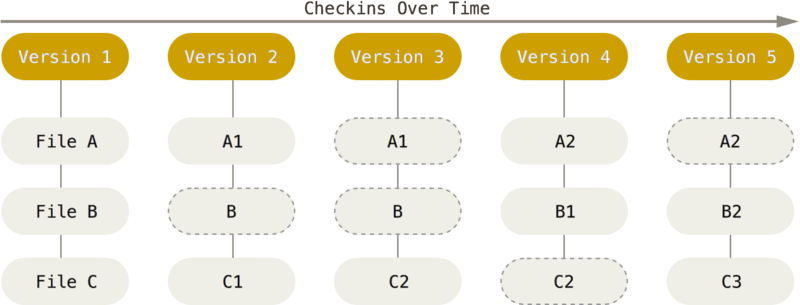

## Conflict free collaboration - a tree like project structure

During technical research projects, which require software of any sorts, conflict free collaboration is key. Conflict free collaboration on software (code) ensures that changes by various collaborators are neatly integrated in the main body of work (or “trunk” in git parlance - with the project or “repository” resembling a tree structure).

From this main trunk various “side projects” or branches by collaborators can sprout. These branches contain code addressing issues in the main trunk, or adding new code, and help in the house-keeping of a software project by allowing for curated integration of these branches into the main trunk. More on how to use this construction in the sections below.

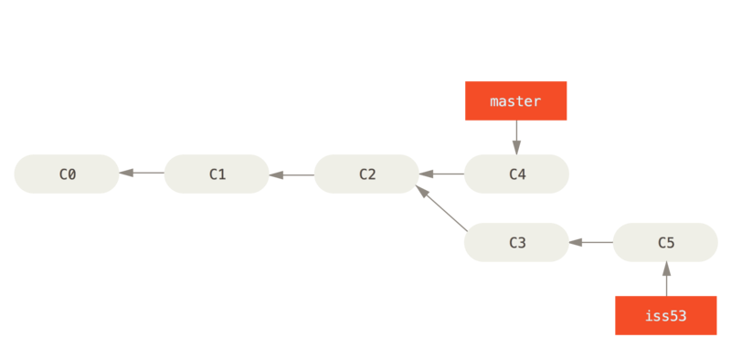

# Git - a research workflow

We now know that git is a versioning software which tracks the state of files of a project. It also allows for different itterations of a project to be “branched” from a main “trunk” in order to facilitate experimentation or resolving file changes without interfering with the original files. Below we’ll see how to implement these concepts into a workflow.

The described workflow will not touch upon all aspects of git, as this is an overly broad topic which easily covers a book. For an in depth discussion on the use of git and all its features we refer to the free “pro” git [e-book / website](https://git-scm.com/book/en/v2).

## creating a local repository

You can create a local git repository using the following commands. You intiate a new git repository in the current working directory (containing your project files) using

```bash
cd /path/to/your/project/
git init
```

This creates a .git directory which tracks all the files you decide to add to this project, and which should reside within the working directory containing this `.git` folder.

Next you can stage files to your git repository by using the command `git add`. The `git add` command flags the files which should be tracked by git. In this case we add all existing `R` code files with a * wildcard, and a README.md file. However, this does not mean that the files are already integrated, this is a promise if you will.

```bash
git add *.R
git add README.md
```

Integrating changes, and any subsequent changes to these files, is done using the `git commit` command. It is often wise to provide your commit command with a message (-m ‘message’) in order to easily find changes should you decide to undo them.

```bash
git commit -m 'Initial project version'
```

With this the added files are integrated into the local git repository. The diagram below outlines this workflow visually.

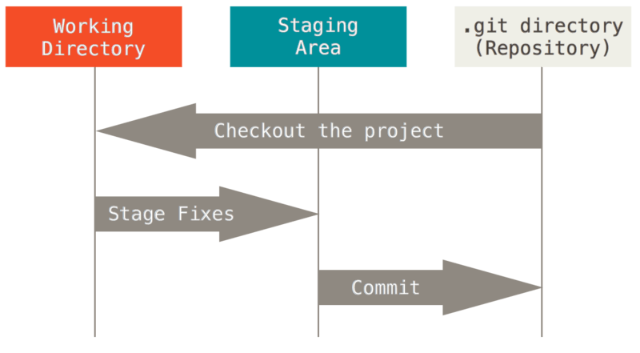

## creating a repository from a remote (github) repository

You can populate a new project using existing remote data using the following command

```bash
git clone https://github.com/libgit2/libgit2
```

In this example you will copy (clone) the git library to your local computer.

## updating a repository (locally)

If files are tracked by git they will require a commit command to update their state and create a new snapshot. For example, adding a line with references to the README.md file can be integrated in your local git project using the following commit

```bash
git commit -m 'adding project references'
```

When commiting changes **include a succinct description of the changes**. Note that by default, changes to multiple files will be combined in one commit. For example, if additional changes were made to *.R files in the directory these would be committed as well.

If you want to commit changes to a specific file using a description limited to this particular file append the filename as such

```bash
git commit -m 'adding project references' README.md
```

## Branches & structuring (local) repository changes

- switching branches, changes the files in your project (remember that git tracks everything as a file)
- conversely, commits (file histories) change with the changed files!
- BUT, nothing is lost, only a selection of the tracked states is shown (locally)!

We can create a branch using the following command

```bash
git branch my_experimental_branch
```

Although this creates a new branch this does not switch us to this branch. To move between branches use the `git checkout` command.

```bash
git checkout my_experimental_branch
```

The checkout option also permits an additional parameter ‘-b’ which allows you to create a new branch and switch to it in one command.

```bash
git checkout -b my_experimental_branch_2
```

## Integrating branches

When making changes to files in a branch no changes will be made to the main project trunk. Obvioulsly, if we are happy with the changes to our branched project, we might want to integrate our changes into the main project. In short, we want to **merge** our changes with the main project trunk. Intuitively, the command to do so is called (you guessed it) `git merge`. To merge a branch into our main (master) project we must switch back to our master trunk. We use the `checkout` command for this.

```bash
git checkout master
```

We then use `git merge` to include the changes of a particular branch into our master/main project.

```bash
git merge my_experimental_branch
```

At times this process will not go smoothly. With git tracking files, if one changes the same file (in the same location) across the main project and a branch git will not know which file snapshot to retain in the main project trunk (is it the changed file in the main project or the same -but altered- file in a branch). We now have a **merge conflict**!

Merge conflicts will be flagged by <<<< ==== >>>> signs, as such

```bash
<<<<<<< HEAD:README.md
the original main text
=======
the original main text - altered in branch 'my_experimental_branch'
>>>>>>> my_experimental_branch:README.md
```

Here the changes to the same file in the main project and the branch are listed side by side, with the top showing the state of the main project and the bottom the state of the branch. You will need to manually edit the afflicted file (removing the <<<< ==== >>>> signs) and running `git commit` create a new snapshot of the files.

Generally merge conflicts should be avoided. They increase the complexity of project management. Avoiding merge conflicts can be achieved through a consistent project workflow. Some tips on this are provided in the following sections.

## A git(hub) workflow

### remote repositories

In the above examples you work with a local git repository. This tracks changes to your code locally, which is helpful, but doesn’t allow for easy collaboration.

For this you need to be able to share your git repository easily. Although self hosting a service is an option it is best to rely on common free services as provided by github or gitlab.

These services allow you to host code projects online, share this code, and provide the necessary tools to easily curate these projects using `git` logic. Basic services are free, more advanced use benefits from a paid account. Overall github is good value for money, considering the scope of what it can do for your work (see side benefits below). For the sake of simplicity we’ll focus on github as a default (workflow) environment. However, gitlab and other services work in similar ways.

Much of the git logic applies directly to actions on github or gitlab. However a few differences are noted, in particular with respect to effectively managing a project workflow. But, to get started we need to create a github project.

### creating a github project

When logged into github (or gitlab) you can easily create a new project using the “new repository” button.

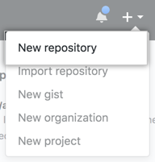

Naming the project and adding a README / LICENSE file will populate the project with these basic files.

[figure not shown]

[figure not shown]

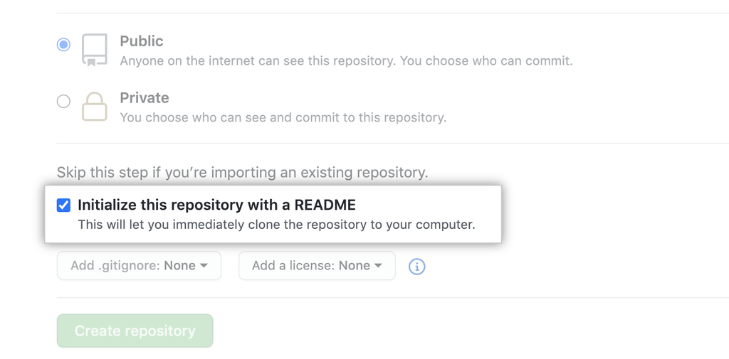

From thereon you can clone the project to your local system as shown above, in this case

```bash
git clone https://github.com/octocat/hello-world
```

### updating a github project

With a local copy of your project you can now add files (`git add`), create new snapshots of changes (`git commit`). However, at this point, these changes are only stored locally. If you’ve cloned your repository from a remote location such as github your local repository is (by default) linked to the remote one, and allows for synchronization of both.

If you’ve made changes to your repository you can update the snapshot on the github servers using the `git push` command. The additional parameters denote where you want to inject the changes (in this case at the head of the trunk).

```bash
git push # --set-upstream origin HEAD
```

A similar logic applies to updating an local repository from the server. For example you’ve made changes on your home computer and pushed these to the github server. You now access a supercomputer to run this code with these novel changes. However, the state of the local repository on the supercomputer will be behind the state of the code on the server. To update your main repository (or branch) to the current state you can run `git pull`.

```bash
git pull
```

This will incorporate changes from a remote repository (on github) into the current branch. By default it will fast-forward the current branch to match the remote github changed files. Always **pull changes from the server before starting to code**. Failing to do so will lead to merge conflicts, and wasted time.

## Managing git(hub) projects

On github, and within open research projects which are generally not too large, the workflow will mostly resemble an integration-manager workflow. Here, all developers work on local copies (either public or private) of a main repository (a clone or fork of the “blessed repository”) and ask the main project’s developer (the integration manager) to integrate these changes by pulling the changes into the main project (i.e. a pull request on github, see below).

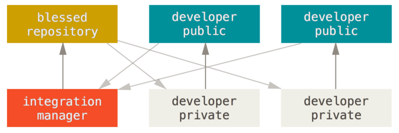

This workflow **balances integration control with collaboration** (assuming that the integration manager is committed to the project). Within the context of a scientific project it is wise to **assign a project lead beforehand**, who will manage the project. All other contributions will be done indirectly, through cloning / forking the project and pulling changes. Generally speaking, having multiple integration managers on the trunk of a project could result in disaster if there is no consensus on the direction of the project.

### Fork & pull request model

With a project on github on you can now track your progress online (as a backup), and work distributed across various systems by pushing or pulling code via git. In short, you can develop code on both your local home computer and a supercomputer at your institute at the same time while keeping track of the state of the project.

However, this model assumes that you are the owner of the github account and will make all these changes yourself. This stands in the way of collaboration. Here github tools come into play to fix this issue, in particular through forking and cloning projects.

A fork is a copy of a repository (a clone) of a project you don’t own. A fork clones an existing project into your github account so you can track changes on this project (locally) as you would with any of your own projects (all the same logic applies).

To make things collaborative github made it possible to push back changes you make on your local fork to the original repository (with permission of the original owner). This action is called a pull request, as analogy to the updating of the local state of a repository you own yourself.

In the top most menu of a github project you will find a `Pull request` tab or button. Clicking this button will link your changes back to the original project.

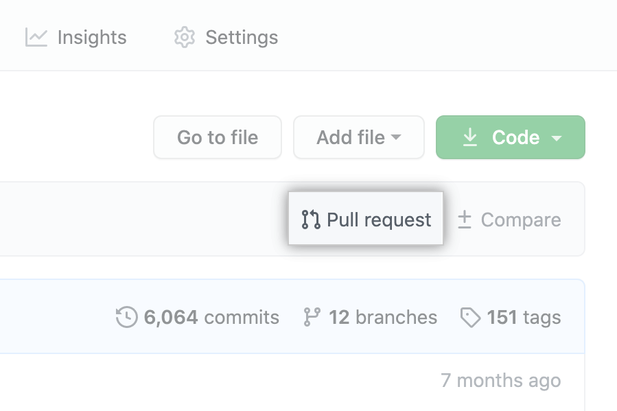

Since you are contributing as an outsider to an existing project you must justify and explain your contributions. Therfore a text window is available to explain the details of your contributions.

[figure not shown]

If you submit the pull request a notification is send to the original owner / project manager. The manager will then check the quality of the code and sign off on integration into the original github project.

If there are concerns the project manager can ask to address these further changes on your end before integration. Note that further commits to your forked project will be added to the current pull request with no further action required.

The example as described here adheres to the integration manager workflow, and is rather foolproof as it requires review at every step. Alternatively you can give other people permission to change the original project. However, this comes with potential dangerous consequences if different project goals are not well communicated internally and people develop in parallel. The latter can lead to complex merge conflicts, which should be avoided.

## Best git workflow patterns in science

Volumes have been written on best practice software development, but these are mostly focussed on commercial and large projects. Small research projects can **relax some of these rules in order to cut back on the undue overhead** it creates on a project lead and members. It is best to balance software development practices with real life expectations and requirements. However, we can make some strong recommendations in this context to simplify some of these decisions and avoid conflicts.

#### Shallow branching patterns & high frequency integration

In the interest of ease of use of smaller projects one should prefer shallow branching and rapid integration. Overall this means that you frequently do pull requests on a cloned or forked main repository while limiting complilcated branching structures, i.e. only simple branches from the main trunk.

Deviating from this pattern will results in frequent complex merge conflicts in low-frequency integration as project members will inadvertadly start to work in parellel on the same files. Thid will generate difficulties propagating new mainline features up branches on top of merge conflicts. For a more in depth discussion I suggest [git branching patterns by Martin Fowler](https://martinfowler.com/articles/branching-patterns.html).

In general there is little need for long lived branches in science workflows. Long lived branches if they exist often cover various “hypothesis”. However, it is better to include these in the main project in a transparent way rather than a separate branch. Should the underlying data structure on which the analysis is built change (in the main project), a statistical test in a branch might fail. These issues will only surface when working on this branch. The longer a branch lives, the more likely it will become to accumulate such operational mismatches.

#### Use unit checks where possible

Unit checks are a way to test code using small (fast) examples. Using unit tests is helpful to verify if the code changes you make do not break either individual functions or other parts of a larger body of code. This of lesser importance when considering a small statistical analysis, but does apply to larger code sections (which might be re-used) such as (internal) packages.

#### Use Issue tracking

Github provides a feature which allows you to create a ticketed issue. Use ticketed issues to state your intentions, even if you develop a new branch. This avoids double work, or once more, merge conflicts due to working on items in parallel.

## collaboration isues

Most common issues within a github workflow relate to merge conflicts. Most of these can be avoided using clear communication using github issues or short lived forks and branches. This is especially true when a project moves quickly.

## Operational safety

Although poor practice it remains common, due to convenience, to store login credentials in the directory of a project. This creates the potential to leak login credentials to public repositories on github. Do not dismiss this warning, [malicious bots actively scan github repositories for potential login credentials](https://edition.cnn.com/2021/02/26/politics/solarwinds123-password-intern/index.html). The latter combined with frequent (partial) password re-use opens you to hackers, fast (mostly within 24h). As such it is unwise to use wildcards (*) while adding files to a github repository.

More so, creating a strong `.gitignore` file is advised. The `.gitignore` file specifies which kind of files to ignore, despite the use a wildcard. This file is a plain text file with the filename `.gitignore` which uses regular expressions to black list certain files from inclusion in the git repository.

When creating an `R` package the default files which are ignored are listed as

```bash
 .Rproj.user
 .Rhistory
 .RData
 .Ruserdata
 inst/doc
```

Please not the inclusion of the `.Rhistory` file! Similar to the leaked credentials issue a history of all commands typed into an (R) terminal might give away login information. For this reason, all command logs (R or otherwise) should not be included in any git project.

## Binary files

Git allows for the storage of binary files without a space penalty. It will detect these files as such and generally will not track changes to these files. However, to ensure that projects don’t grow in size due to binary files in the project you can specify additional parameters in the `.gitattributes` file. Similar to the `.gitignore` file this is a plain text file with parameters, in this case file types to ignore logging state differences for.

Flagging files explicitly as “binary” is often wise when dealing with files which are text but are not human readable. An example would be postscript files, as a precursor to a rendered PDF. Or, when including large sized CSV files with data. The below `.gitattributes` file would ignore creating verbose differences between two files. Thes settings forces the file types to be treated as if binary.

```bash
*.ps -diff
*.csv -diff
```

# R & RStudio git integration

In the above workflow we relied on command line tools. Although it is valuable to know these commands in many work environments you will be able to rely on an Integrated Development Environment (IDE) such as RStudio or VSCode. Both these interfaces provide a unified place in which you write code, visualize analysis (if applicable) and manage your git repository.

## creating a git enabled R project

### linking a remote repository

# Github side benefits

There is a whole set of not well advertized side benefits to owning and paying for a github account.

- website hosting (free) + easy domain integration (https)
- hosting of various web data integrated in websites
- automation of various tasks (github actions) mostly unit checks and continuous integration
- automatically building website updates
- generous and easily accessed data storage (if the data is open free)

# References

- Figures pertaining to the git workflow are licensed as CC-SA-NC 3.0 from the Pro Git book by Scott Chacon and Ben Straub and is [available online](https://git-scm.com/book/en/v2).
- Figures on the use of github sourced from [Github Docs](https://docs.github.com/en).